# AP-4209 ESIEE-Paris: 2023 -2024

Fouille de données avec R pour la data science et l’intelligence artificielle

III.TD 3 : Partie I - MANOVA

Badr TAJINI – ESIEE Paris  
Source : Bertrand Roudier – ESIEE Paris **Code complété par Paul Cascarino et Mathis Quinio-Cosquer**

### 1. Introduction

Ce TD a pour objectif de réaliser une analyse de variance multivariée (MANOVA) en développant une fonction dédiée. Nous utilisons dans un premier temps un jeu de données simple (exemple vu en cours) ou tous les résultats intermédiaires vous sont fournis.

Une fois votre code intégré dans une fonction, vous vérifiez vos résultats en comparaison avec les résultats fournis par la fonction *manova* de R sur un jeu de données de volumétrie plus importante.

Une partie du code que vous allez développer nous servira pour la suite lorsque nous aborderons l’analyse factorielle discriminante ; principalement le calcul des inerties inter classes, intra classes et totales

### 2 Rappels

La somme des carrés des écarts total (SCT = Inertie Totale) est la résultante (comme en ANOVA) de la sommes des carrés intra classes (SCresiduelle = SC Intra ) et de la somme des carrés inter classes (SC Ecart = SC Inter)
$$\sum\limits_{i = 1}^n
{{d^2}({x_i},g)} = \sum\limits_{j = 1}^k {{n_j}{d^2}} ({g_j},g) +
\sum\limits_{j = 1}^k {\sum\limits_{i = 1}^{{n_k}}
{{d^2}({x_{i,j}},{g_j})} }$$

Si nous considérons le jeu de données comme étant la population, nous pouvons directement estimer les variances inter classes et intra classes :
$$\frac{1}{n}\sum\limits_{i = 1}^n
{{d^2}({x_i},g)} = \frac{1}{n}\sum\limits_{j = 1}^k {{n_j}{d^2}}
({g_j},g) + \frac{1}{n}\sum\limits_{j = 1}^k {\sum\limits_{i =
1}^{{n_k}} {{d^2}({x_{i,j}},{g_j})} }$$
Pour réaliser le test de comparaison des groupes, nous calculons

1. la somme des carrés Totaux: *SST*
2. La somme des carrés Intra: *SS intra*
3. La somme des carrés Inter par différence : *SS inter = SS Tot - SS intra*
4. la ratio des déterminants: *Det(SS intra) / Det(SS total)*
5. La valeur critique qui suit une distribution de *Chi-Deux* et qui nous permet de réaliser le test

### 3 Pré-requis

Avant de calculer les inerties (SS), et pour rendre le code le plus générique possible, nous devons créer :

- Une variable *N* qui correspond aux nombre totale d’individus
- Une variable *P* qui correspond aux nombres de variables
- Un data frame des variables prédictives *X*
- Un vecteur *Y* de la variable catégorielle
- Une variable *K* qui correspond aux nombres de groupes (catégories)
- Une liste *XK* dont chaque élément contient les individus de chaque groupes
- Un vecteur *NK* qui correspond aux nombres d’individus par groupe
- Une liste *GK* dont chaque élément contient la moyenne des variables de chaque groupe (catégorie)
- Un vecteur *G* dont chaque élément est la moyenne générale (hors groupe) de chaque variable

Nous utilisons le fichier : *MANOVA_DATASET.csv*. Ce jeu de données comprend

- 26 observations
- 5 variables explicatives numériques
- 1 variable factorielle comprenant 4 niveaux (catégories) > Note : le fichier **MANOVA_DATASET.csv** doit être transformé en fichier **MANOVA_DATASET.Rda** pour être utilisé dans votre TD correctement.

rmq: Il s’agit ici d’étudier l’existence d’une différence entre la composition chimique de différentes des poteries antiques retrouvées dans des fouilles archéologiques.

- **Installation des packages nécessaires :**

```r
rm(list=ls())
```

- **Chargement des packages nécessaires :**

```r
library(kableExtra)
library(help = "datasets")
```

- **Première étape :**

```r
# Récupération de nos données
df <- read.csv("MANOVA_DATASET.csv", header = TRUE)
head(df)
```

```
##        Site   Al   Fe   Mg   Ca   Na
## 1 Llanedyrn 14.4 7.00 4.30 0.15 0.51
## 2 Llanedyrn 13.8 7.08 3.43 0.12 0.17
## 3 Llanedyrn 14.6 7.09 3.88 0.13 0.20
## 4 Llanedyrn 11.5 6.37 5.64 0.16 0.14
## 5 Llanedyrn 13.8 7.06 5.34 0.20 0.20
## 6 Llanedyrn 10.9 6.26 3.47 0.17 0.22
```

**Explication :** Le header = TRUE indique que le première ligne contient le nom des colonnes

- **Seconde étape :**

```r
# On renomme la colonne Site en Class
df$Class <- df$Site
df$Site <- NULL
head(df)
```

```
##     Al   Fe   Mg   Ca   Na     Class
## 1 14.4 7.00 4.30 0.15 0.51 Llanedyrn
## 2 13.8 7.08 3.43 0.12 0.17 Llanedyrn
## 3 14.6 7.09 3.88 0.13 0.20 Llanedyrn
## 4 11.5 6.37 5.64 0.16 0.14 Llanedyrn
## 5 13.8 7.06 5.34 0.20 0.20 Llanedyrn
## 6 10.9 6.26 3.47 0.17 0.22 Llanedyrn
```

**Explication :** Permet plus de clareté, on supprime l’ancienne colonne.

- **Troisième étape :**

Les données sont les suivantes :

```r
# Transformation de Class en factor
df$Class <- as.factor(substr(df$Class,1,2))
head(df)
```

```
##     Al   Fe   Mg   Ca   Na Class
## 1 14.4 7.00 4.30 0.15 0.51    Ll
## 2 13.8 7.08 3.43 0.12 0.17    Ll
## 3 14.6 7.09 3.88 0.13 0.20    Ll
## 4 11.5 6.37 5.64 0.16 0.14    Ll
## 5 13.8 7.06 5.34 0.20 0.20    Ll
## 6 10.9 6.26 3.47 0.17 0.22    Ll
```

**Explication :** On ne garde que les 2 premières lettres de nos facteurs

- **Quatrième étape :**

```r
save(df, file = 'MANOVA_DATASET.Rda')
```

**Explication :** Permet de conserver notre dataframe qui est plus propre

- **Sixième étape :**

```r
summary(df)
```

```
##        Al              Fe              Mg              Ca
##  Min.   :10.10   Min.   :0.920   Min.   :0.530   Min.   :0.0100
##  1st Qu.:11.95   1st Qu.:1.700   1st Qu.:0.670   1st Qu.:0.0600
##  Median :13.80   Median :5.465   Median :3.825   Median :0.1550
##  Mean   :14.49   Mean   :4.468   Mean   :3.142   Mean   :0.1465
##  3rd Qu.:17.45   3rd Qu.:6.590   3rd Qu.:4.503   3rd Qu.:0.2150
##  Max.   :20.80   Max.   :7.090   Max.   :7.230   Max.   :0.3100
##        Na         Class
##  Min.   :0.0300   As: 5
##  1st Qu.:0.0500   Ca: 2
##  Median :0.1500   Is: 5
##  Mean   :0.1585   Ll:14
##  3rd Qu.:0.2150
##  Max.   :0.5400
```

- **Septième étape :**

```r
df %>% kbl(digits=3) %>%
       kable_styling(bootstrap_options = "striped", full_width = F, position = "center", latex_options = 'stripped') %>%
       scroll_box( height = "250px")
```

| Al | Fe | Mg | Ca | Na | Class |
| --- | --- | --- | --- | --- | --- |
| 14.4 | 7.00 | 4.30 | 0.15 | 0.51 | Ll |
| 13.8 | 7.08 | 3.43 | 0.12 | 0.17 | Ll |
| 14.6 | 7.09 | 3.88 | 0.13 | 0.20 | Ll |
| 11.5 | 6.37 | 5.64 | 0.16 | 0.14 | Ll |
| 13.8 | 7.06 | 5.34 | 0.20 | 0.20 | Ll |
| 10.9 | 6.26 | 3.47 | 0.17 | 0.22 | Ll |
| 10.1 | 4.26 | 4.26 | 0.20 | 0.18 | Ll |
| 11.6 | 5.78 | 5.91 | 0.18 | 0.16 | Ll |
| 11.1 | 5.49 | 4.52 | 0.29 | 0.30 | Ll |
| 13.4 | 6.92 | 7.23 | 0.28 | 0.20 | Ll |
| 12.4 | 6.13 | 5.69 | 0.22 | 0.54 | Ll |
| 13.1 | 6.64 | 5.51 | 0.31 | 0.24 | Ll |
| 12.7 | 6.69 | 4.45 | 0.20 | 0.22 | Ll |
| 12.5 | 6.44 | 3.94 | 0.22 | 0.23 | Ll |
| 11.8 | 5.44 | 3.94 | 0.30 | 0.04 | Ca |
| 11.6 | 5.39 | 3.77 | 0.29 | 0.06 | Ca |
| 18.3 | 1.28 | 0.67 | 0.03 | 0.03 | Is |
| 15.8 | 2.39 | 0.63 | 0.01 | 0.04 | Is |
| 18.0 | 1.50 | 0.67 | 0.01 | 0.06 | Is |
| 18.0 | 1.88 | 0.68 | 0.01 | 0.04 | Is |
| 20.8 | 1.51 | 0.72 | 0.07 | 0.10 | Is |
| 17.7 | 1.12 | 0.56 | 0.06 | 0.06 | As |
| 18.3 | 1.14 | 0.67 | 0.06 | 0.05 | As |
| 16.7 | 0.92 | 0.53 | 0.01 | 0.05 | As |
| 14.8 | 2.74 | 0.67 | 0.03 | 0.05 | As |
| 19.1 | 1.64 | 0.60 | 0.10 | 0.03 | As |

Résultat attendu du nouveau dataset après la création de notre pipeline ELT (Extract-Load-Transform) :

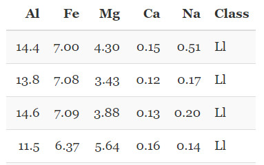

- **Nombre total d’individus *N***

```r
N <- nrow(df)
paste("Nombre d'individus N = ",N)
```

```
## [1] "Nombre d'individus N =  26"
```

- **Nombre de variables prédictives *P***

Le calcul du nombre de variables prédictives doit être réalisé de manière automatique. Pour y parvenir, on peut, par exemple, identifier les colonnes des variables numériques et calculer la longueur du vecteur des identifiants (utilisation des fonctions *which* et *sapply*)

```r
P <- ncol(df)-1
paste("Nombre de variables prédictives P = ", P)
```

```
## [1] "Nombre de variables prédictives P =  5"
```

- **Le dataframe *X* des variables prédictives**

```r
X <- subset(df, select = -c(Class))
head(X)
```

```
##     Al   Fe   Mg   Ca   Na
## 1 14.4 7.00 4.30 0.15 0.51
## 2 13.8 7.08 3.43 0.12 0.17
## 3 14.6 7.09 3.88 0.13 0.20
## 4 11.5 6.37 5.64 0.16 0.14
## 5 13.8 7.06 5.34 0.20 0.20
## 6 10.9 6.26 3.47 0.17 0.22
```

**Explication :** On retire notre variable Class pour conserver uniquement nos prédicteurs

- **Variable catégorielle sous forme d’un vecteur *Y***

```r
Y <- df$Class
Y
```

```
##  [1] Ll Ll Ll Ll Ll Ll Ll Ll Ll Ll Ll Ll Ll Ll Ca Ca Is Is Is Is Is As As As As
## [26] As
## Levels: As Ca Is Ll
```

- **Variable *K* qui correspond aux nombres de groupes (catégories)**

```r
K <- length(levels(Y))
K
```

```
## [1] 4
```

**Explication :** levels(Y) donne le nom de classe de Y, ainsi il suffit de trouver la longueur de ce vecteur

- **Liste *XK* dont chaque élément contient les individus de chaque groupes**

Pour y parvenir, nous pouvons utiliser la fonction *split*. Les éléments sont les suivants :

```r
XK <- split(X, Y)
XK
```

```
## $As
##      Al   Fe   Mg   Ca   Na
## 22 17.7 1.12 0.56 0.06 0.06
## 23 18.3 1.14 0.67 0.06 0.05
## 24 16.7 0.92 0.53 0.01 0.05
## 25 14.8 2.74 0.67 0.03 0.05
## 26 19.1 1.64 0.60 0.10 0.03
##
## $Ca
##      Al   Fe   Mg   Ca   Na
## 15 11.8 5.44 3.94 0.30 0.04
## 16 11.6 5.39 3.77 0.29 0.06
##
## $Is
##      Al   Fe   Mg   Ca   Na
```

[output cut: 22 more lines]

- **Vecteur *NK* qui correspond aux nombres d’individus par groupe**

```r
NK <- table(Y)
NK
```

```
## Y
## As Ca Is Ll
##  5  2  5 14
```

- **Liste *GK* dont chaque élément contient la moyenne des variables de chaque groupe (catégorie)**

```r
GK <- lapply(XK, colMeans)
GK
```

```
## $As
##     Al     Fe     Mg     Ca     Na
## 17.320  1.512  0.606  0.052  0.048
##
## $Ca
##     Al     Fe     Mg     Ca     Na
## 11.700  5.415  3.855  0.295  0.050
##
## $Is
##     Al     Fe     Mg     Ca     Na
## 18.180  1.712  0.674  0.026  0.054
##
## $Ll
##         Al         Fe         Mg         Ca         Na
## 12.5642857  6.3721429  4.8264286  0.2021429  0.2507143
```

**Explication :** Nous voulons pour chaque groupe, sa moyenne d’où l’utilisation du lapply afin d’appliquer la fonction pour tous les groupes. Ce processus sera répété plusieurs fois

- **Vecteur *G* dont chaque élément est la moyenne générale (hors groupe) de chaque variable**

```r
G <- lapply(X, mean)
G
```

```
## $Al
## [1] 14.49231
##
## $Fe
## [1] 4.467692
##
## $Mg
## [1] 3.141538
##
## $Ca
## [1] 0.1465385
##
## $Na
## [1] 0.1584615
```

### 4. Calcul des Inerties

#### 4.1 Inertie totale

La Somme des carrés totaux (Inertie Totale) correspond à la sommes des carrés des distances entre l’ensemble des observations et la moyenne générale :

$${I_{total}} = \sum\limits_{i = 1}^n
{{d^2}({x_i},g)}$$

Nous pouvons la calculer directement à l’aide du calcul matriciel suivant :
$${I_{Tot}} = SST = {(X - G)^t}
\times (X - G)$$

Pour y parvenir nous devons :

1. Transformer le dataframe en matrice (NxP)
2. Créer une matrice de même taille (NxP) dont chaque ligne correspond au vecteur G
3. Calculer la différence
4. Effectuer la multiplication avec transposition du premier élément

Au finale, la matrice (*SS_tot*) est la suivante :

```r
# Création dee X_matrix
X_matrix <- X
colnames(X_matrix) <- NULL
rownames(X_matrix) <- NULL
X_matrix <- as.matrix(X_matrix)
X_matrix
```

```
##       [,1] [,2] [,3] [,4] [,5]
##  [1,] 14.4 7.00 4.30 0.15 0.51
##  [2,] 13.8 7.08 3.43 0.12 0.17
##  [3,] 14.6 7.09 3.88 0.13 0.20
##  [4,] 11.5 6.37 5.64 0.16 0.14
##  [5,] 13.8 7.06 5.34 0.20 0.20
##  [6,] 10.9 6.26 3.47 0.17 0.22
##  [7,] 10.1 4.26 4.26 0.20 0.18
##  [8,] 11.6 5.78 5.91 0.18 0.16
##  [9,] 11.1 5.49 4.52 0.29 0.30
## [10,] 13.4 6.92 7.23 0.28 0.20
## [11,] 12.4 6.13 5.69 0.22 0.54
## [12,] 13.1 6.64 5.51 0.31 0.24
## [13,] 12.7 6.69 4.45 0.20 0.22
## [14,] 12.5 6.44 3.94 0.22 0.23
## [15,] 11.8 5.44 3.94 0.30 0.04
## [16,] 11.6 5.39 3.77 0.29 0.06
## [17,] 18.3 1.28 0.67 0.03 0.03
## [18,] 15.8 2.39 0.63 0.01 0.04
## [19,] 18.0 1.50 0.67 0.01 0.06
## [20,] 18.0 1.88 0.68 0.01 0.04
## [21,] 20.8 1.51 0.72 0.07 0.10
## [22,] 17.7 1.12 0.56 0.06 0.06
## [23,] 18.3 1.14 0.67 0.06 0.05
## [24,] 16.7 0.92 0.53 0.01 0.05
## [25,] 14.8 2.74 0.67 0.03 0.05
## [26,] 19.1 1.64 0.60 0.10 0.03
```

```r
# Création d'une matrix ayant la moyenne de chaque variable hors grouep
G_tot <- matrix(rep(as.numeric(G), N), nrow = N, ncol = P, byrow = TRUE)
G_tot
```

```
##           [,1]     [,2]     [,3]      [,4]      [,5]
##  [1,] 14.49231 4.467692 3.141538 0.1465385 0.1584615
##  [2,] 14.49231 4.467692 3.141538 0.1465385 0.1584615
##  [3,] 14.49231 4.467692 3.141538 0.1465385 0.1584615
##  [4,] 14.49231 4.467692 3.141538 0.1465385 0.1584615
##  [5,] 14.49231 4.467692 3.141538 0.1465385 0.1584615
##  [6,] 14.49231 4.467692 3.141538 0.1465385 0.1584615
##  [7,] 14.49231 4.467692 3.141538 0.1465385 0.1584615
##  [8,] 14.49231 4.467692 3.141538 0.1465385 0.1584615
##  [9,] 14.49231 4.467692 3.141538 0.1465385 0.1584615
## [10,] 14.49231 4.467692 3.141538 0.1465385 0.1584615
## [11,] 14.49231 4.467692 3.141538 0.1465385 0.1584615
## [12,] 14.49231 4.467692 3.141538 0.1465385 0.1584615
## [13,] 14.49231 4.467692 3.141538 0.1465385 0.1584615
## [14,] 14.49231 4.467692 3.141538 0.1465385 0.1584615
## [15,] 14.49231 4.467692 3.141538 0.1465385 0.1584615
## [16,] 14.49231 4.467692 3.141538 0.1465385 0.1584615
## [17,] 14.49231 4.467692 3.141538 0.1465385 0.1584615
## [18,] 14.49231 4.467692 3.141538 0.1465385 0.1584615
## [19,] 14.49231 4.467692 3.141538 0.1465385 0.1584615
## [20,] 14.49231 4.467692 3.141538 0.1465385 0.1584615
## [21,] 14.49231 4.467692 3.141538 0.1465385 0.1584615
## [22,] 14.49231 4.467692 3.141538 0.1465385 0.1584615
## [23,] 14.49231 4.467692 3.141538 0.1465385 0.1584615
## [24,] 14.49231 4.467692 3.141538 0.1465385 0.1584615
## [25,] 14.49231 4.467692 3.141538 0.1465385 0.1584615
## [26,] 14.49231 4.467692 3.141538 0.1465385 0.1584615
```

```r
# On fait la différence
Diff_matrix <- X_matrix - G_tot
Diff_matrix
```

```
##              [,1]       [,2]       [,3]         [,4]         [,5]
##  [1,] -0.09230769  2.5323077  1.1584615  0.003461538  0.351538462
##  [2,] -0.69230769  2.6123077  0.2884615 -0.026538462  0.011538462
##  [3,]  0.10769231  2.6223077  0.7384615 -0.016538462  0.041538462
##  [4,] -2.99230769  1.9023077  2.4984615  0.013461538 -0.018461538
##  [5,] -0.69230769  2.5923077  2.1984615  0.053461538  0.041538462
##  [6,] -3.59230769  1.7923077  0.3284615  0.023461538  0.061538462
##  [7,] -4.39230769 -0.2076923  1.1184615  0.053461538  0.021538462
##  [8,] -2.89230769  1.3123077  2.7684615  0.033461538  0.001538462
##  [9,] -3.39230769  1.0223077  1.3784615  0.143461538  0.141538462
## [10,] -1.09230769  2.4523077  4.0884615  0.133461538  0.041538462
## [11,] -2.09230769  1.6623077  2.5484615  0.073461538  0.381538462
## [12,] -1.39230769  2.1723077  2.3684615  0.163461538  0.081538462
## [13,] -1.79230769  2.2223077  1.3084615  0.053461538  0.061538462
## [14,] -1.99230769  1.9723077  0.7984615  0.073461538  0.071538462
## [15,] -2.69230769  0.9723077  0.7984615  0.153461538 -0.118461538
## [16,] -2.89230769  0.9223077  0.6284615  0.143461538 -0.098461538
## [17,]  3.80769231 -3.1876923 -2.4715385 -0.116538462 -0.128461538
## [18,]  1.30769231 -2.0776923 -2.5115385 -0.136538462 -0.118461538
## [19,]  3.50769231 -2.9676923 -2.4715385 -0.136538462 -0.098461538
## [20,]  3.50769231 -2.5876923 -2.4615385 -0.136538462 -0.118461538
## [21,]  6.30769231 -2.9576923 -2.4215385 -0.076538462 -0.058461538
## [22,]  3.20769231 -3.3476923 -2.5815385 -0.086538462 -0.098461538
## [23,]  3.80769231 -3.3276923 -2.4715385 -0.086538462 -0.108461538
## [24,]  2.20769231 -3.5476923 -2.6115385 -0.136538462 -0.108461538
## [25,]  0.30769231 -1.7276923 -2.4715385 -0.116538462 -0.108461538
## [26,]  4.60769231 -2.8276923 -2.5415385 -0.046538462 -0.128461538
```

```r
# On fait le produit matriciel de saa transposé à elle même afin d'obtenir SS_tot
SS_tot <- t(Diff_matrix) %*% Diff_matrix
SS_tot
```

```
##             [,1]        [,2]        [,3]       [,4]       [,5]
## [1,]  223.898462 -142.215462 -130.201692 -5.7826923 -4.7833077
## [2,] -142.215462  145.172462  118.272092  4.6665923  5.3927077
## [3,] -130.201692  118.272092  118.780138  4.6445385  4.7381615
## [4,]   -5.782692    4.666592    4.644538  0.2561885  0.1648615
## [5,]   -4.783308    5.392708    4.738162  0.1648615  0.4575385
```

**Explication :** On convertit notre X en matrix puis on soustrait chacune de ses variables par la moyenne de chaque variable hors groupe. On la mets ensuite au carré en effectuant un produit matriciel.

#### 4.2 Inertie intra classe

Nous allons, dans un premier temps calculer, pour chaque groupe, le somme des carrés des écarts entre les individus de ce groupe et la moyenne de chaque groupe. Les Inerties intra partielles sont stockées dans une liste (*SS_partiel_Intra*).

Pour chaque classe, nous calculons la SS intra (partielle) :
$$S{S_{{\text{k}}{\text{, intra}}}} =
\sum\limits_{i = 1}^{{n_k}} {{d^2}({x_{i,j}},{g_j})} = {({X_{ik}} -
{G_k})^t} \times ({X_{ik}} - {G_k})$$

Les résultats sont les suivants:

```r
# Création d'une liste vide pour stocker les différences
SS_tot_intra <- list()

for (key in names(XK)) {
  XK_matrix <- XK[[key]]
  # On retire les noms de colonnes et lignes pour éviter un bug
  colnames(XK_matrix) <- NULL
  rownames(XK_matrix) <- NULL
  XK_matrix <- as.matrix(XK_matrix)
  GK_matrix <- matrix(rep(as.numeric(GK[[key]]), nrow(XK_matrix)), nrow = nrow(XK_matrix), byrow = TRUE)
  Diff_matrix_inter <- XK_matrix - GK_matrix
  # On retire les noms de colonnes et lignes pour éviter un bug
  colnames(Diff_matrix_inter) <- NULL
  rownames(Diff_matrix_inter) <- NULL

  print(Diff_matrix_inter)

  SS_tot_intra[[key]] <- t(Diff_matrix_inter) %*% Diff_matrix_inter
}
```

```
##       [,1]   [,2]   [,3]   [,4]   [,5]
## [1,]  0.38 -0.392 -0.046  0.008  0.012
## [2,]  0.98 -0.372  0.064  0.008  0.002
## [3,] -0.62 -0.592 -0.076 -0.042  0.002
## [4,] -2.52  1.228  0.064 -0.022  0.002
## [5,]  1.78  0.128 -0.006  0.048 -0.018
##      [,1]   [,2]   [,3]   [,4]  [,5]
## [1,]  0.1  0.025  0.085  0.005 -0.01
## [2,] -0.1 -0.025 -0.085 -0.005  0.01
##       [,1]   [,2]   [,3]   [,4]   [,5]
## [1,]  0.12 -0.432 -0.004  0.004 -0.024
## [2,] -2.38  0.678 -0.044 -0.016 -0.014
## [3,] -0.18 -0.212 -0.004 -0.016  0.006
## [4,] -0.18  0.168  0.006 -0.016 -0.014
## [5,]  2.62 -0.202  0.046  0.044  0.046
##              [,1]         [,2]       [,3]         [,4]        [,5]
##  [1,]  1.83571429  0.627857143 -0.5264286 -0.052142857  0.25928571
##  [2,]  1.23571429  0.707857143 -1.3964286 -0.082142857 -0.08071429
##  [3,]  2.03571429  0.717857143 -0.9464286 -0.072142857 -0.05071429
##  [4,] -1.06428571 -0.002142857  0.8135714 -0.042142857 -0.11071429
##  [5,]  1.23571429  0.687857143  0.5135714 -0.002142857 -0.05071429
##  [6,] -1.66428571 -0.112142857 -1.3564286 -0.032142857 -0.03071429
##  [7,] -2.46428571 -2.112142857 -0.5664286 -0.002142857 -0.07071429
##  [8,] -0.96428571 -0.592142857  1.0835714 -0.022142857 -0.09071429
##  [9,] -1.46428571 -0.882142857 -0.3064286  0.087857143  0.04928571
## [10,]  0.83571429  0.547857143  2.4035714  0.077857143 -0.05071429
## [11,] -0.16428571 -0.242142857  0.8635714  0.017857143  0.28928571
## [12,]  0.53571429  0.267857143  0.6835714  0.107857143 -0.01071429
## [13,]  0.13571429  0.317857143 -0.3764286 -0.002142857 -0.03071429
## [14,] -0.06428571  0.067857143 -0.8864286  0.017857143 -0.02071429
```

```r
SS_tot_intra
```

```
## $As
##         [,1]     [,2]     [,3]     [,4]     [,5]
## [1,] 11.0080 -3.01320 -0.07960  0.17780 -0.03180
## [2,] -3.0132  2.16688  0.11704 -0.00212 -0.00648
## [3,] -0.0796  0.11704  0.01612  0.00164 -0.00034
## [4,]  0.1778 -0.00212  0.00164  0.00468 -0.00088
## [5,] -0.0318 -0.00648 -0.00034 -0.00088  0.00048
##
## $Ca
##        [,1]     [,2]     [,3]     [,4]    [,5]
## [1,]  0.020  0.00500  0.01700  0.00100 -0.0020
## [2,]  0.005  0.00125  0.00425  0.00025 -0.0005
## [3,]  0.017  0.00425  0.01445  0.00085 -0.0017
## [4,]  0.001  0.00025  0.00085  0.00005 -0.0001
## [5,] -0.002 -0.00050 -0.00170 -0.00010  0.0002
##
## $Is
##         [,1]     [,2]     [,3]     [,4]     [,5]
## [1,] 12.6080 -2.18680  0.22440  0.15960  0.15240
## [2,] -2.1868  0.76028 -0.03554 -0.02076 -0.01204
## [3,]  0.2244 -0.03554  0.00412  0.00268  0.00272
## [4,]  0.1596 -0.02076  0.00268  0.00272  0.00228
## [5,]  0.1524 -0.01204  0.00272  0.00228  0.00312
##
## $Ll
##            [,1]        [,2]        [,3]         [,4]        [,5]
## [1,] 24.6521429 12.27507143  0.44621429 -0.231928571 0.470357143
## [2,] 12.2750714  8.02243571  0.44130714 -0.132564286 0.085778571
## [3,]  0.4462143  0.44130714 15.39492143  0.430207143 0.026935714
## [4,] -0.2319286 -0.13256429  0.43020714  0.044035714 0.008778571
## [5,]  0.4703571  0.08577857  0.02693571  0.008778571 0.195492857
```

**Explication :** Même principe que précedemment mais cette fois ci à l’intérieur de chaque classes.

Les K matrices sont ensuite additionnées pour obtenir l’inertie Intra (*SS_Intra*),

$$S{S_{{\text{intra }}}} = \sum\limits_{j
= 1}^k {\sum\limits_{i = 1}^{{n_k}} {{d^2}({x_{i,j}},{g_j})} } =
\sum\limits_{j = 1}^k {{{({X_{ik}} - {G_k})}^t} \times ({X_{ik}} -
{G_k})}$$

```r
SS_intra <- Reduce(`+`, SS_tot_intra)
SS_intra
```

```
##            [,1]        [,2]        [,3]        [,4]       [,5]
## [1,] 48.2881429  7.08007143  0.60801429  0.10647143 0.58895714
## [2,]  7.0800714 10.95084571  0.52705714 -0.15519429 0.06675857
## [3,]  0.6080143  0.52705714 15.42961143  0.43537714 0.02761571
## [4,]  0.1064714 -0.15519429  0.43537714  0.05148571 0.01007857
## [5,]  0.5889571  0.06675857  0.02761571  0.01007857 0.19929286
```

#### 4.3 Inertie inter classe

L’inertie inter classe s’obtient directement par différence.

$$S{S_{{\text{inter}}}} = S{S_{tot}} -
S{S_{{\text{intra}}}}$$

```r
SS_inter <- SS_tot - SS_intra
SS_inter
```

```
##             [,1]        [,2]        [,3]       [,4]       [,5]
## [1,]  175.610319 -149.295533 -130.809707 -5.8891637 -5.3722648
## [2,] -149.295533  134.221616  117.745035  4.8217866  5.3259491
## [3,] -130.809707  117.745035  103.350527  4.2091613  4.7105458
## [4,]   -5.889164    4.821787    4.209161  0.2047027  0.1547830
## [5,]   -5.372265    5.325949    4.710546  0.1547830  0.2582456
```

### 5. Inférence Statistique

#### 5.1 Calcul du Lambda

$$\Lambda = \frac{{\left| {{I_W}}
\right|}}{{\left| {{I_B} + {I_W}} \right|}} = \frac{{\left|
{S{S_{{\text{intra}}}}} \right|}}{{\left| {S{S_{{\text{inter}}}} +
S{S_{{\text{intra}}}}} \right|}}$$

```r
lambda <- det(SS_intra) / (det(SS_inter + SS_intra))
lambda
```

```
## [1] 0.01230091
```

**Explication :** Nous utilisons le lambda de notre test de Wilks

#### 5.2 Correction

$$- \left( {n - 1 - \frac{{P + K}}{2}}
\right)\ln (\Lambda )$$

```r
correction <- -(N-1-(P+K)/2)*log(lambda)
correction
```

```
## [1] 90.16069
```

**Explication :** notre correction correspond à la quantité de notre test de Wilks

#### 5.3 Conclusions

```r
degre <- K-1
alpha <- 0.05

valeur_critique <- qchisq(1 - alpha, degre)
valeur_critique
```

```
## [1] 7.814728
```

**Explication :** On utilise qchisq pour effectuer notre test de Wilks.

La valeur critique est très inférieure à la valeur corrigée. En conclusion, on rejette l’hypothèse nulle d’égalité des moyennes. On peut donc affirmer que les catégories différent très significativement. Au TD III partie 2, nous allons réaliser le même type de test sur des plans factoriels (Analyse Factorielle Discriminante) ce qui permettra d’obtenir des représentations graphiques de positionnement des différents groupes et des variables associées qui sont essentielles pour de la fouille de données qu’elles soient réalisées en R ou en Python !

### 6 Validation

Nous comparons maintenant les résultats avec la fonction manova de R

```r
X
```

```
##      Al   Fe   Mg   Ca   Na
## 1  14.4 7.00 4.30 0.15 0.51
## 2  13.8 7.08 3.43 0.12 0.17
## 3  14.6 7.09 3.88 0.13 0.20
## 4  11.5 6.37 5.64 0.16 0.14
## 5  13.8 7.06 5.34 0.20 0.20
## 6  10.9 6.26 3.47 0.17 0.22
## 7  10.1 4.26 4.26 0.20 0.18
## 8  11.6 5.78 5.91 0.18 0.16
## 9  11.1 5.49 4.52 0.29 0.30
## 10 13.4 6.92 7.23 0.28 0.20
## 11 12.4 6.13 5.69 0.22 0.54
## 12 13.1 6.64 5.51 0.31 0.24
## 13 12.7 6.69 4.45 0.20 0.22
## 14 12.5 6.44 3.94 0.22 0.23
## 15 11.8 5.44 3.94 0.30 0.04
## 16 11.6 5.39 3.77 0.29 0.06
## 17 18.3 1.28 0.67 0.03 0.03
## 18 15.8 2.39 0.63 0.01 0.04
## 19 18.0 1.50 0.67 0.01 0.06
## 20 18.0 1.88 0.68 0.01 0.04
## 21 20.8 1.51 0.72 0.07 0.10
## 22 17.7 1.12 0.56 0.06 0.06
## 23 18.3 1.14 0.67 0.06 0.05
## 24 16.7 0.92 0.53 0.01 0.05
## 25 14.8 2.74 0.67 0.03 0.05
## 26 19.1 1.64 0.60 0.10 0.03
```

```r
Y
```

```
##  [1] Ll Ll Ll Ll Ll Ll Ll Ll Ll Ll Ll Ll Ll Ll Ca Ca Is Is Is Is Is As As As As
## [26] As
## Levels: As Ca Is Ll
```

```r
manova_res <- manova(as.matrix(X) ~ Y)
summary(manova_res)
```

```
##           Df Pillai approx F num Df den Df    Pr(>F)
## Y          3 1.5539   4.2984     15     60 2.413e-05 ***
## Residuals 22
## ---
## Signif. codes:  0 '***' 0.001 '**' 0.01 '*' 0.05 '.' 0.1 ' ' 1
```

**Explication :** Nous avons une valeur de test de 1.5539 ce qui nettement supérieur à 0,0123. Nous pensons que c’est parce que le test réalisé est le test de Pillai et non de Wilks. Ainsi regardons comment effectuer le bon test :

```r
X
```

```
##      Al   Fe   Mg   Ca   Na
## 1  14.4 7.00 4.30 0.15 0.51
## 2  13.8 7.08 3.43 0.12 0.17
## 3  14.6 7.09 3.88 0.13 0.20
## 4  11.5 6.37 5.64 0.16 0.14
## 5  13.8 7.06 5.34 0.20 0.20
## 6  10.9 6.26 3.47 0.17 0.22
## 7  10.1 4.26 4.26 0.20 0.18
## 8  11.6 5.78 5.91 0.18 0.16
## 9  11.1 5.49 4.52 0.29 0.30
## 10 13.4 6.92 7.23 0.28 0.20
## 11 12.4 6.13 5.69 0.22 0.54
## 12 13.1 6.64 5.51 0.31 0.24
## 13 12.7 6.69 4.45 0.20 0.22
## 14 12.5 6.44 3.94 0.22 0.23
## 15 11.8 5.44 3.94 0.30 0.04
## 16 11.6 5.39 3.77 0.29 0.06
## 17 18.3 1.28 0.67 0.03 0.03
## 18 15.8 2.39 0.63 0.01 0.04
## 19 18.0 1.50 0.67 0.01 0.06
## 20 18.0 1.88 0.68 0.01 0.04
## 21 20.8 1.51 0.72 0.07 0.10
## 22 17.7 1.12 0.56 0.06 0.06
## 23 18.3 1.14 0.67 0.06 0.05
## 24 16.7 0.92 0.53 0.01 0.05
## 25 14.8 2.74 0.67 0.03 0.05
## 26 19.1 1.64 0.60 0.10 0.03
```

```r
Y
```

```
##  [1] Ll Ll Ll Ll Ll Ll Ll Ll Ll Ll Ll Ll Ll Ll Ca Ca Is Is Is Is Is As As As As
## [26] As
## Levels: As Ca Is Ll
```

```r
manova_res <- manova(as.matrix(X) ~ Y)
summary(manova_res, test='Wilks')
```

```
##           Df    Wilks approx F num Df den Df   Pr(>F)
## Y          3 0.012301   13.088     15 50.091 1.84e-12 ***
## Residuals 22
## ---
## Signif. codes:  0 '***' 0.001 '**' 0.01 '*' 0.05 '.' 0.1 ' ' 1
```

### 7 Fonctions

A partir du code que vous avez développé, construire une fonction générique (*MANOVA*) qui retourne sous forme de listes :

- SS_tot
- SS_Intra
- SS_Inter
- Gk
- G
- NK
- P
- N
- Lambda
- La probabilité associés au test(cf cours)

Nous testons cette fonction avec le fichier *iris* fourni par defaut dans R Cette fonction nous servira au prochain TD lorsque nous réaliserons une analyse factorielle discriminante

```r
  my_manova <- function(X, Y) {
    final <- list()

    final$N <- nrow(X)
    final$P <- ncol(X) - 1

    K <- length(levels(Y))
    XK <- split(X, Y)
    final$NK <- table(Y)

    final$GK <- lapply(XK, colMeans)

    final$G <- lapply(X, mean)

    # Transformer le dataframe en matrice (NxP)
    X_matrix <- X
    X_matrix <- as.matrix(X_matrix)
    G_tot <- matrix(rep(as.numeric(final$G), final$N),
                    nrow = nrow(X_matrix),
                    byrow = TRUE)
    Diff_matrix <- X_matrix - G_tot
    final$SS_tot <- t(Diff_matrix) %*% Diff_matrix

    SS_tot_intra <- list()
    for (key in names(XK)) {
      XK_matrix <- as.matrix(XK[[key]])
      GK_matrix <- matrix(rep(as.numeric(final$GK[[key]]),
                              nrow(XK_matrix)),
                          nrow = nrow(XK_matrix),
                          byrow = TRUE)
      # Calcul de la différence et stockage dans la liste
      Diff_matrix_inter <- XK_matrix - GK_matrix
      SS_tot_intra[[key]] <- t(Diff_matrix_inter) %*% Diff_matrix_inter
    }
    final$SS_intra <- Reduce(`+`, SS_tot_intra)

    final$SS_inter <- final$SS_tot - final$SS_intra

    final$lambda <- det(final$SS_intra) / (det(final$SS_inter + final$SS_intra))

    correction <- -(final$N - 1 - (final$P + K)/2) * log(final$lambda)
    degre <- (K-1)
    final$proba <- qchisq(1 - alpha, degre)

    return(final)
  }
```

Le jeux de données est le suivant

```r
test <- my_manova(X,Y)
test
```

```
## $N
## [1] 26
##
## $P
## [1] 4
##
## $NK
## Y
## As Ca Is Ll
##  5  2  5 14
##
## $GK
## $GK$As
##     Al     Fe     Mg     Ca     Na
## 17.320  1.512  0.606  0.052  0.048
##
## $GK$Ca
##     Al     Fe     Mg     Ca     Na
## 11.700  5.415  3.855  0.295  0.050
##
## $GK$Is
##     Al     Fe     Mg     Ca     Na
## 18.180  1.712  0.674  0.026  0.054
##
## $GK$Ll
##         Al         Fe         Mg         Ca         Na
## 12.5642857  6.3721429  4.8264286  0.2021429  0.2507143
##
##
## $G
## $G$Al
## [1] 14.49231
##
## $G$Fe
## [1] 4.467692
##
## $G$Mg
## [1] 3.141538
##
## $G$Ca
```

[output cut: 20 more lines]

```
## Na  0.5889571  0.06675857  0.02761571  0.01007857 0.19929286
##
## $SS_inter
##             Al          Fe          Mg         Ca         Na
## Al  175.610319 -149.295533 -130.809707 -5.8891637 -5.3722648
## Fe -149.295533  134.221616  117.745035  4.8217866  5.3259491
## Mg -130.809707  117.745035  103.350527  4.2091613  4.7105458
## Ca   -5.889164    4.821787    4.209161  0.2047027  0.1547830
## Na   -5.372265    5.325949    4.710546  0.1547830  0.2582456
##
## $lambda
## [1] 0.01230091
##
## $proba
## [1] 7.814728
```

```r
iris_df <- iris
head(iris_df)
```

```
##   Sepal.Length Sepal.Width Petal.Length Petal.Width Species
## 1          5.1         3.5          1.4         0.2  setosa
## 2          4.9         3.0          1.4         0.2  setosa
## 3          4.7         3.2          1.3         0.2  setosa
## 4          4.6         3.1          1.5         0.2  setosa
## 5          5.0         3.6          1.4         0.2  setosa
## 6          5.4         3.9          1.7         0.4  setosa
```

```r
Y_iris <- iris_df$Species
X_iris <- subset(iris_df, select = -c(Species))

test_iris <- my_manova(X_iris,Y_iris)
test_iris
```

```
## $N
## [1] 150
##
## $P
## [1] 3
##
## $NK
## Y
##     setosa versicolor  virginica
##         50         50         50
##
## $GK
## $GK$setosa
## Sepal.Length  Sepal.Width Petal.Length  Petal.Width
##        5.006        3.428        1.462        0.246
##
## $GK$versicolor
## Sepal.Length  Sepal.Width Petal.Length  Petal.Width
##        5.936        2.770        4.260        1.326
##
## $GK$virginica
## Sepal.Length  Sepal.Width Petal.Length  Petal.Width
##        6.588        2.974        5.552        2.026
##
##
## $G
## $G$Sepal.Length
## [1] 5.843333
##
## $G$Sepal.Width
## [1] 3.057333
##
## $G$Petal.Length
## [1] 3.758
##
## $G$Petal.Width
## [1] 1.199333
##
##
## $SS_tot
```

[output cut: 10 more lines]

```
## Petal.Length      24.6246      8.1208      27.2226      6.2718
## Petal.Width        5.6450      4.8084       6.2718      6.1566
##
## $SS_inter
##              Sepal.Length Sepal.Width Petal.Length Petal.Width
## Sepal.Length     63.21213   -19.95267     165.2484    71.27933
## Sepal.Width     -19.95267    11.34493     -57.2396   -22.93267
## Petal.Length    165.24840   -57.23960     437.1028   186.77400
## Petal.Width      71.27933   -22.93267     186.7740    80.41333
##
## $lambda
## [1] 0.02343863
##
## $proba
## [1] 5.991465
```

l’utilisation de la fonction *manova* de R conduit à la même valeur du lambda… Une fois de plus, vous avez bien travaillé !

```r
  manova_iris <- manova(as.matrix(X_iris) ~ Y_iris)
  summary(manova_iris, test='Wilks')
```

```
##            Df    Wilks approx F num Df den Df    Pr(>F)
## Y_iris      2 0.023439   199.15      8    288 < 2.2e-16 ***
## Residuals 147
## ---
## Signif. codes:  0 '***' 0.001 '**' 0.01 '*' 0.05 '.' 0.1 ' ' 1
```

**Explication :** De même retrouvons bien les mêmes valeurs : 0,023439, cela valide notre fonction !